# R Notebook

Proteomics analysis

Proteomics - separate Bright and Dark - Run Raw data - PCA (2 separate) - DGE - results - plot volcanos : Thresholds to include: Log2FC > 0.5 and padjusted < 0.05 - Pathway analysis - KEGG and GO all Heatmap of pathways

```r
library(readxl)
```

```r
colnames(df.bright)
```

```
 [1] "Checked"
 [2] "Protein FDR Confidence: Combined"
 [3] "Master"
 [4] "Accession"
 [5] "Description"
 [6] "Abundance Ratio (log2): (A53T_6_weeks) / (AIW_6_weeks)"
 [7] "Abundance Ratio (log2): (GBA_6_weeks) / (AIW_6_weeks)"
 [8] "Abundance Ratio (log2): (PINK1_6_weeks) / (AIW_6_weeks)"
 [9] "Abundance Ratio (log2): (PRKN_6_weeks) / (AIW_6_weeks)"
[10] "Abundance Ratio P-Value: (A53T_6_weeks) / (AIW_6_weeks)"
[11] "Abundance Ratio P-Value: (GBA_6_weeks) / (AIW_6_weeks)"
[12] "Abundance Ratio P-Value: (PINK1_6_weeks) / (AIW_6_weeks)"
[13] "Abundance Ratio P-Value: (PRKN_6_weeks) / (AIW_6_weeks)"
[14] "Abundances (Grouped) CV [%]: A53T_6_weeks"
[15] "Abundances (Grouped) CV [%]: AIW_6_weeks"
```

[output cut: 21 more lines]

Separate out the normalized abundance data from the DPE analysis (Abundance ratio log2)

```r
bright.ab <- df.bright[, c(4, 21:36)]
head(bright.ab)
```

| Accession | Abundances (Grouped): (Normalized): F2: 128C, Sample, A53T_6_weeks, A53T_6_weeks_1 | Abundances (Grouped): (Normalized): F2: 129N, Sample, A53T_6_weeks, A53T_6_weeks_2 | Abundances (Grouped): (Normalized): F2: 129C, Sample, A53T_6_weeks, A53T_6_weeks_3 | Abundances (Grouped): (Normalized): F2: 127N, Control, AIW_6_weeks, A1W_6_weeks_1 | Abundances (Grouped): (Normalized): F2: 127C, Control, AIW_6_weeks, A1W_6_weeks_2 | Abundances (Grouped): (Normalized): F2: 128N, Control, AIW_6_weeks, A1W_6_weeks_3 | Abundances (Grouped): (Normalized): F2: 130N, Sample, GBA_6_weeks, GBA_6_weeks_1 | Abundances (Grouped): (Normalized): F2: 130C, Sample, GBA_6_weeks, GBA_6_weeks_2 | Abundances (Grouped): (Normalized): F2: 131N, Sample, GBA_6_weeks, GBA_6_weeks_3 | Abundances (Grouped): (Normalized): F2: 131C, Sample, PINK1_6_weeks, PINK1_6_weeks_1 | Abundances (Grouped): (Normalized): F2: 132N, Sample, PINK1_6_weeks, PINK1_6_weeks_2 | Abundances (Grouped): (Normalized): F2: 132C, Sample, PINK1_6_weeks, PINK1_6_weeks_3 | Abundances (Grouped): (Normalized): F2: 126, Sample, Pool, Pool2 | Abundances (Grouped): (Normalized): F2: 133N, Sample, PRKN_6_weeks, PRKN_6_weeks_1 | Abundances (Grouped): (Normalized): F2: 133C, Sample, PRKN_6_weeks, PRKN_6_weeks_2 | Abundances (Grouped): (Normalized): F2: 134N, Sample, PRKN_6_weeks, PRKN_6_weeks_3 |
| --- | --- | --- | --- | --- | --- | --- | --- | --- | --- | --- | --- | --- | --- | --- | --- | --- |
| Q9Y276 | NA | NA | 5.3 | NA | NA | NA | 8.2 | 27.8 | 22.6 | 20.3 | 11.3 | 25.9 | 19.9 | 21.3 | 19.8 | 18.5 |
| P08754 | 9.8 | 9.5 | 10.6 | NA | NA | NA | 5.8 | 16.8 | 12.8 | 14.4 | 24.6 | 20.5 | 17.4 | 27.7 | 21.2 | 21.2 |
| A0A1X7SBT7 | 9.1 | 9.1 | 8.5 | NA | NA | NA | 5.2 | NA | 9.7 | 7.6 | 7.1 | 14.3 | 10.9 | 27.1 | 35.8 | 23.0 |
| Q9H4D0 | 8.6 | NA | 10.8 | NA | NA | NA | 7.2 | 13.2 | NA | 8.4 | 8.2 | 9.8 | 16.1 | 32.9 | 43.3 | 16.9 |
| Q496J9 | 14.1 | NA | 12.5 | NA | NA | NA | NA | NA | 6.8 | 2.7 | NA | 6.1 | 9.4 | 33.7 | 39.1 | 33.9 |
| P62760 | 250.3 | 247.5 | 273.5 | 32.3 | 66.5 | 35 | 55.4 | 106.0 | 61.4 | 166.5 | 120.5 | 169.5 | 179.1 | 259.1 | 252.9 | 231.3 |

```r
colnames(bright.ab)
```

```
 [1] "Accession"
 [2] "Abundances (Grouped): (Normalized): F2: 128C, Sample, A53T_6_weeks, A53T_6_weeks_1"
 [3] "Abundances (Grouped): (Normalized): F2: 129N, Sample, A53T_6_weeks, A53T_6_weeks_2"
 [4] "Abundances (Grouped): (Normalized): F2: 129C, Sample, A53T_6_weeks, A53T_6_weeks_3"
 [5] "Abundances (Grouped): (Normalized): F2: 127N, Control, AIW_6_weeks, A1W_6_weeks_1"
 [6] "Abundances (Grouped): (Normalized): F2: 127C, Control, AIW_6_weeks, A1W_6_weeks_2"
 [7] "Abundances (Grouped): (Normalized): F2: 128N, Control, AIW_6_weeks, A1W_6_weeks_3"
 [8] "Abundances (Grouped): (Normalized): F2: 130N, Sample, GBA_6_weeks, GBA_6_weeks_1"
 [9] "Abundances (Grouped): (Normalized): F2: 130C, Sample, GBA_6_weeks, GBA_6_weeks_2"
[10] "Abundances (Grouped): (Normalized): F2: 131N, Sample, GBA_6_weeks, GBA_6_weeks_3"
[11] "Abundances (Grouped): (Normalized): F2: 131C, Sample, PINK1_6_weeks, PINK1_6_weeks_1"
[12] "Abundances (Grouped): (Normalized): F2: 132N, Sample, PINK1_6_weeks, PINK1_6_weeks_2"
[13] "Abundances (Grouped): (Normalized): F2: 132C, Sample, PINK1_6_weeks, PINK1_6_weeks_3"
[14] "Abundances (Grouped): (Normalized): F2: 126, Sample, Pool, Pool2"
[15] "Abundances (Grouped): (Normalized): F2: 133N, Sample, PRKN_6_weeks, PRKN_6_weeks_1"
[16] "Abundances (Grouped): (Normalized): F2: 133C, Sample, PRKN_6_weeks, PRKN_6_weeks_2"
[17] "Abundances (Grouped): (Normalized): F2: 134N, Sample, PRKN_6_weeks, PRKN_6_weeks_3"
```

Rename samples All the samples are 6 weeks DA neurons from iPSC lines in the AIW002-02 background

```r
colnames(bright.ab) <- c("Protein","A53T-1","A53T-2","A53T-3","Control-1","Control-2","Control-3","GBA.KO-1","GBA.KO-2","GBA.KO-3","PINK1.KO-1","PINK1.KO-2","PINK1.KO-3","POOL","PRKN.KO-1","PRKN.KO-2","PRKN.KO-3")
```

Calculate and plot PCA - removing proteins with NA values

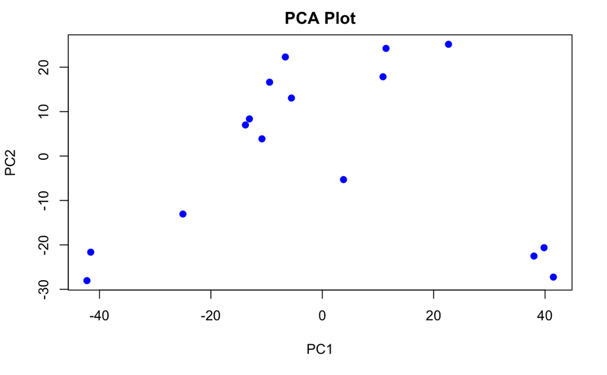

```r
# Step 1: Handle missing values
# Remove rows with any NA values
df_clean <- na.omit(bright.ab)

# We go from 4111 proteins to 1876

# make the protein column in to the row names
rownames(df_clean) <- df_clean$Protein
df_clean <- df_clean[, 2:17]

# Step 2: Transpose the data so that rows are samples and columns are proteins
df_t <- t(df_clean)

# Step 3: Perform PCA
pca_result <- prcomp(df_t, scale. = TRUE)

# Step 4: Extract the PCA scores for the first two dimensions
pca_scores <- as.data.frame(pca_result$x)

# Step 5: Plot the PCA
plot(pca_scores$PC1, pca_scores$PC2,
     xlab = "PC1",
     ylab = "PC2",
     main = "PCA Plot",
     pch = 19, # Solid circles
     col = "blue") # Color of the points
```

```r
NA
NA
NA
```

```r
rownames(pca_scores)
```

```
 [1] "A53T-1"     "A53T-2"     "A53T-3"     "Control-1"  "Control-2"  "Control-3"  "GBA.KO-1"   "GBA.KO-2"   "GBA.KO-3"   "PINK1.KO-1" "PINK1.KO-2"
[12] "PINK1.KO-3" "POOL"       "PRKN.KO-1"  "PRKN.KO-2"  "PRKN.KO-3"
```

Plot coloured by samples

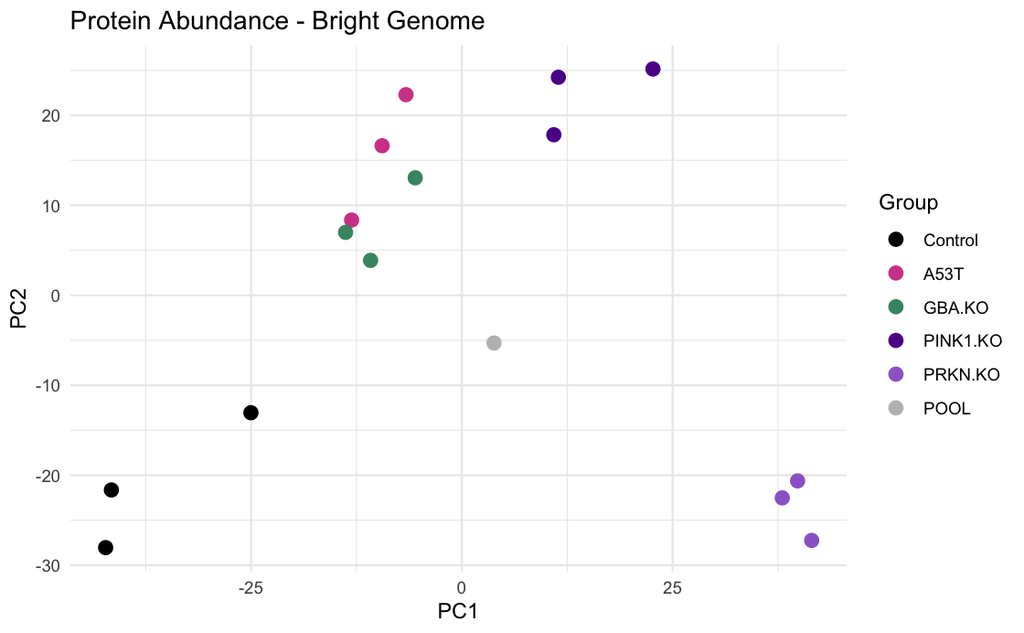

Repeat for the Dark genome

```r
colnames(df.dark)
```

```
 [1] "Checked"                                                              "Protein FDR Confidence: Combined"
 [3] "Master"                                                               "Accession"
 [5] "Description"                                                          "Abundance Ratio (log2): (IGSF9B) / (CTRL)"
 [7] "Abundance Ratio (log2): (INPP5F) / (CTRL)"                            "Abundance Ratio (log2): (IP6K2) / (CTRL)"
 [9] "Abundance Ratio (log2): (SH3GL2) / (CTRL)"                            "Abundance Ratio P-Value: (IGSF9B) / (CTRL)"
[11] "Abundance Ratio P-Value: (INPP5F) / (CTRL)"                           "Abundance Ratio P-Value: (IP6K2) / (CTRL)"
[13] "Abundance Ratio P-Value: (SH3GL2) / (CTRL)"                           "Abundances (Grouped) CV [%]: CTRL"
[15] "Abundances (Grouped) CV [%]: IGSF9B"                                  "Abundances (Grouped) CV [%]: INPP5F"
[17] "Abundances (Grouped) CV [%]: IP6K2"                                   "Abundances (Grouped) CV [%]: POOL"
[19] "Abundances (Grouped) CV [%]: SH3GL2"                                  "# Unique Peptides"
[21] "Found in Sample: [S1] F1: 126, Sample, CTRL, CTRL-1"                  "Found in Sample: [S2] F1: 127N, Sample, CTRL, CTRL-2"
[23] "Found in Sample: [S3] F1: 127C, Sample, CTRL, CTRL-3"                 "Found in Sample: [S4] F1: 128N, Sample, CTRL, CTRL-4"
[25] "Found in Sample: [S14] F1: 133N, Sample, IGSF9B, IGSF9B-1"            "Found in Sample: [S15] F1: 133C, Sample, IGSF9B, IGSF9B-2"
[27] "Found in Sample: [S8] F1: 130N, Sample, INPP5F, INPP5F-1"             "Found in Sample: [S9] F1: 130C, Sample, INPP5F, INPP5F-2"
[29] "Found in Sample: [S10] F1: 131N, Sample, INPP5F, INPP5F-3"            "Found in Sample: [S5] F1: 128C, Sample, IP6K2, IP6K2-1"
[31] "Found in Sample: [S6] F1: 129N, Sample, IP6K2, IP6K2-2"               "Found in Sample: [S7] F1: 129C, Sample, IP6K2, IP6K2-4"
[33] "Found in Sample: [S16] F1: 134N, Sample, POOL, POOL"                  "Found in Sample: [S11] F1: 131C, Sample, SH3GL2, SH3GL2-1"
[35] "Found in Sample: [S12] F1: 132N, Sample, SH3GL2, SH3GL2-2"            "Found in Sample: [S13] F1: 132C, Sample, SH3GL2, SH3GL2-3"
[37] "# Protein Groups"                                                     "Abundances (Grouped): Normalized: F1: 126, Sample, CTRL, CTRL-1"
[39] "Abundances (Grouped): Normalized: F1: 127N, Sample, CTRL, CTRL-2"     "Abundances (Grouped): Normalized: F1: 127C, Sample, CTRL, CTRL-3"
[41] "Abundances (Grouped): Normalized: F1: 128N, Sample, CTRL, CTRL-4"     "Abundances (Grouped): Normalized: F1: 133N, Sample, IGSF9B, IGSF9B-1"
[43] "Abundances (Grouped): Normalized: F1: 133C, Sample, IGSF9B, IGSF9B-2" "Abundances (Grouped): Normalized: F1: 130N, Sample, INPP5F, INPP5F-1"
[45] "Abundances (Grouped): Normalized: F1: 130C, Sample, INPP5F, INPP5F-2" "Abundances (Grouped): Normalized: F1: 131N, Sample, INPP5F, INPP5F-3"
[47] "Abundances (Grouped): Normalized: F1: 128C, Sample, IP6K2, IP6K2-1"   "Abundances (Grouped): Normalized: F1: 129N, Sample, IP6K2, IP6K2-2"
[49] "Abundances (Grouped): Normalized: F1: 129C, Sample, IP6K2, IP6K2-4"   "Abundances (Grouped): Normalized: F1: 134N, Sample, POOL, POOL"
[51] "Abundances (Grouped): Normalized: F1: 131C, Sample, SH3GL2, SH3GL2-1" "Abundances (Grouped): Normalized: F1: 132N, Sample, SH3GL2, SH3GL2-2"
[53] "Abundances (Grouped): Normalized: F1: 132C, Sample, SH3GL2, SH3GL2-3"
```

```r
colnames(dark.ab)
```

```
 [1] "Accession"                                                            "Abundances (Grouped): Normalized: F1: 126, Sample, CTRL, CTRL-1"
 [3] "Abundances (Grouped): Normalized: F1: 127N, Sample, CTRL, CTRL-2"     "Abundances (Grouped): Normalized: F1: 127C, Sample, CTRL, CTRL-3"
 [5] "Abundances (Grouped): Normalized: F1: 128N, Sample, CTRL, CTRL-4"     "Abundances (Grouped): Normalized: F1: 133N, Sample, IGSF9B, IGSF9B-1"
 [7] "Abundances (Grouped): Normalized: F1: 133C, Sample, IGSF9B, IGSF9B-2" "Abundances (Grouped): Normalized: F1: 130N, Sample, INPP5F, INPP5F-1"
 [9] "Abundances (Grouped): Normalized: F1: 130C, Sample, INPP5F, INPP5F-2" "Abundances (Grouped): Normalized: F1: 131N, Sample, INPP5F, INPP5F-3"
[11] "Abundances (Grouped): Normalized: F1: 128C, Sample, IP6K2, IP6K2-1"   "Abundances (Grouped): Normalized: F1: 129N, Sample, IP6K2, IP6K2-2"
[13] "Abundances (Grouped): Normalized: F1: 129C, Sample, IP6K2, IP6K2-4"   "Abundances (Grouped): Normalized: F1: 134N, Sample, POOL, POOL"
[15] "Abundances (Grouped): Normalized: F1: 131C, Sample, SH3GL2, SH3GL2-1" "Abundances (Grouped): Normalized: F1: 132N, Sample, SH3GL2, SH3GL2-2"
[17] "Abundances (Grouped): Normalized: F1: 132C, Sample, SH3GL2, SH3GL2-3"
```

Rename samples All the samples are 6 weeks DA neurons from iPSC lines in the AIW002-02 background

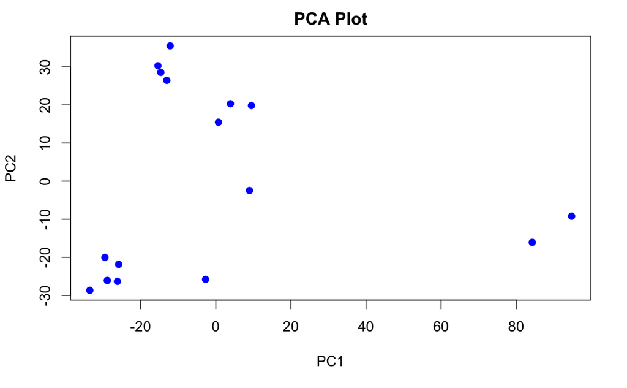

```r
colnames(dark.ab) <- c("Protein","Control-1",
                       "Control-2","Control-3",
                       "Control-4","IGSF9B.KO-1",
                       "IGSF9B.KO-2","INPP5F.KO-1",
                       "INPP5F.KO-2","INPP5F.KO-3",
                       "IP6K2.KO-1","IP6K2.KO-2",
                       "IP6K2.KO-4","POOL",
                       "SH3GL2.KO-1","SH3GL2.KO-2","SH3GL2.KO-3")



# Step 1: Handle missing values
# Remove rows with any NA values
df_clean2 <- na.omit(dark.ab)

# We go from 4111 proteins to 1876

# make the protein column in to the row names
rownames(df_clean2) <- df_clean2$Protein
df_clean2 <- df_clean2[, 2:17]


# Step 2: Transpose the data so that rows are samples and columns are proteins
df_t2 <- t(df_clean2)

# Step 3: Perform PCA
pca_result2 <- prcomp(df_t2, scale. = TRUE)

# Step 4: Extract the PCA scores for the first two dimensions
pca_scores2 <- as.data.frame(pca_result2$x)

# Step 5: Plot the PCA
plot(pca_scores2$PC1, pca_scores2$PC2,
     xlab = "PC1",
     ylab = "PC2",
     main = "PCA Plot",
     pch = 19, # Solid circles
     col = "blue") # Color of the points
```

```r
NA
NA
NA
```

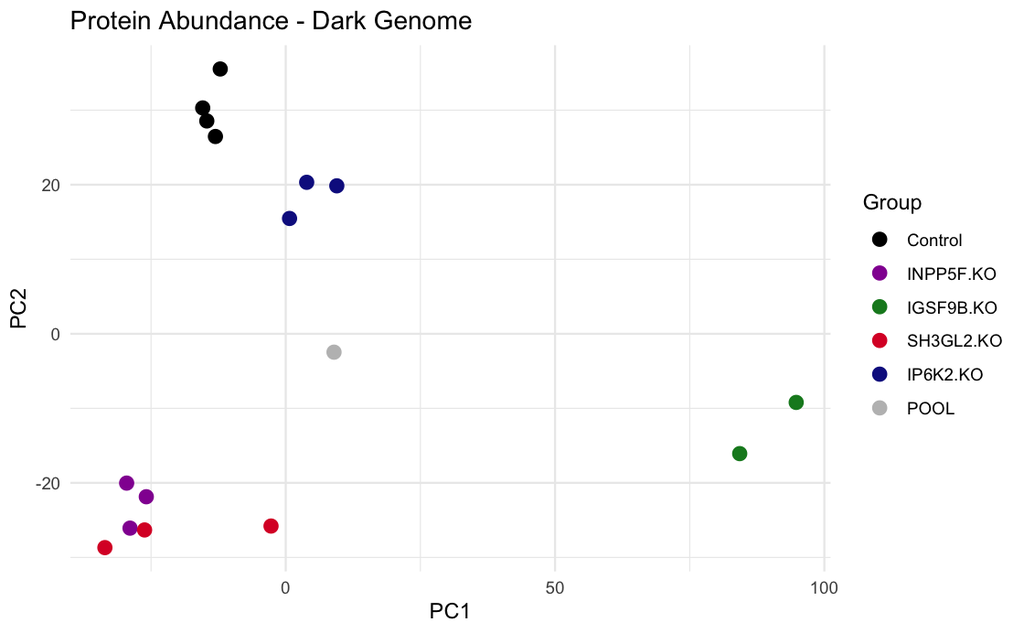

```r
# Step 1: Extract group information from row names
# Assuming row names are in the format "Group-Sample" (e.g., "A53T-1", "Control-1")
sample_names <- rownames(pca_scores2)
sample_groups <- gsub("-.*", "", sample_names)



# Step 2: Add the group information to the PCA scores dataframe
pca_scores2$Group <- factor(sample_groups, levels = c("Control", "INPP5F.KO", "IGSF9B.KO", "SH3GL2.KO","IP6K2.KO", "POOL"))



# take colours from Roxanne's plots: c("Control"= black, "INPP5F.KO" = Purple pinkish, "IGSF9B.KO" = green, "SH3GL2.KO" = red,"IP6K2.KO" = dark blue, "POOL"))
# green "#5c9e4b",
custom_colours <- c("black","#931ea0","#148825","#db072f","#111e8f","grey")

ggplot(pca_scores2, aes(x = PC1, y = PC2, color = Group)) +
  geom_point(size = 3) +
  labs(title = "Protein Abundance - Dark Genome", x = "PC1", y = "PC2") +
  scale_color_manual(values = custom_colours)+
  theme_minimal()
```

```r
NA
NA
```

How does it look if I combine the data?

```r
colnames(df_joined)
```

[output not shown]

```r
df_clean_all <- na.omit(df_joined)

# We go from 6352 to 1338

# make the protein column in to the row names
rownames(df_clean_all) <- df_clean_all$Protein


# remove the Protein column
rownames(df_clean_all) <- df_clean_all$Protein
df_clean_all <- df_clean_all[, 2:33]


# Step 2: Transpose the data so that rows are samples and columns are proteins
df_t3 <- t(df_clean_all)

# Step 3: Perform PCA
pca_result3 <- prcomp(df_t3, scale. = TRUE)

# Step 4: Extract the PCA scores for the first two dimensions
pca_scores3 <- as.data.frame(pca_result3$x)
```

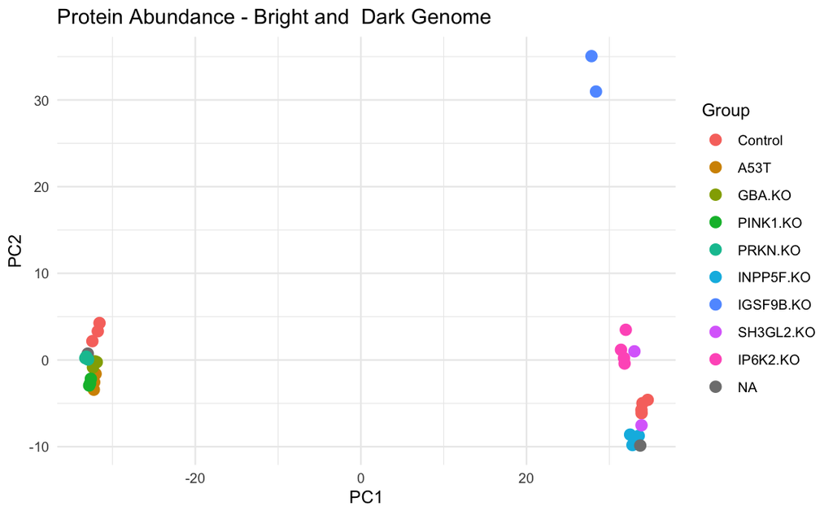

Try some quick normalization

[figure not shown]

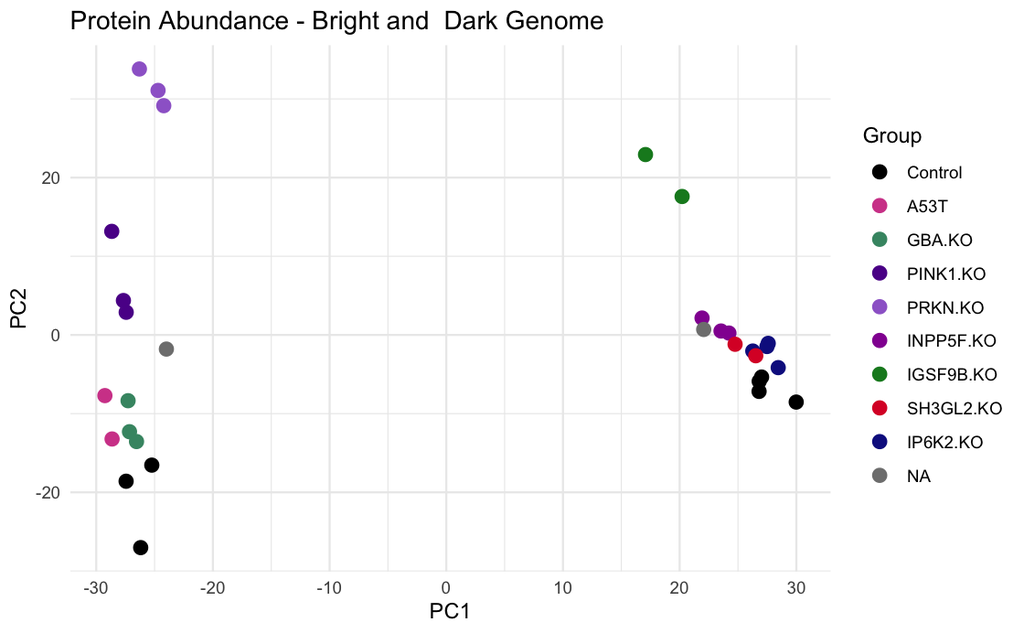

```r
normalized_df <- as.data.frame(scale(df_clean_all[, -1]))

# Step 2: Transpose the data so that rows are samples and columns are proteins
df_t3 <- t(normalized_df)

# Step 3: Perform PCA
pca_result3 <- prcomp(df_t3, scale. = TRUE)

# Step 4: Extract the PCA scores for the first two dimensions
pca_scores3 <- as.data.frame(pca_result3$x)


# Step 1: Extract group information from row names
# Assuming row names are in the format "Group-Sample" (e.g., "A53T-1", "Control-1")
sample_names <- rownames(pca_scores3)
sample_groups <- gsub("-.*", "", sample_names)



# Step 2: Add the group information to the PCA scores dataframe
pca_scores3$Group <- factor(sample_groups, levels = c("Control","A53T", "GBA.KO", "PINK1.KO", "PRKN.KO", "INPP5F.KO", "IGSF9B.KO", "SH3GL2.KO","IP6K2.KO", "POOL"))


# take colours from Roxanne's plots: c("Control"= black, "INPP5F.KO" = Purple pinkish, "IGSF9B.KO" = green, "SH3GL2.KO" = red,"IP6K2.KO" = dark blue, "POOL"))
# green "#5c9e4b",
custom_colours <- c("black","#d34a98","#439472","#5c1c97","#9e69cf","#931ea0","#148825","#db072f","#111e8f","grey")

ggplot(pca_scores3, aes(x = PC1, y = PC2, color = Group)) +
  geom_point(size = 3) +
  labs(title = "Protein Abundance - Bright and  Dark Genome", x = "PC1", y = "PC2") +
 scale_color_manual(values = custom_colours)+
  theme_minimal()
```

```r
NA
NA
```

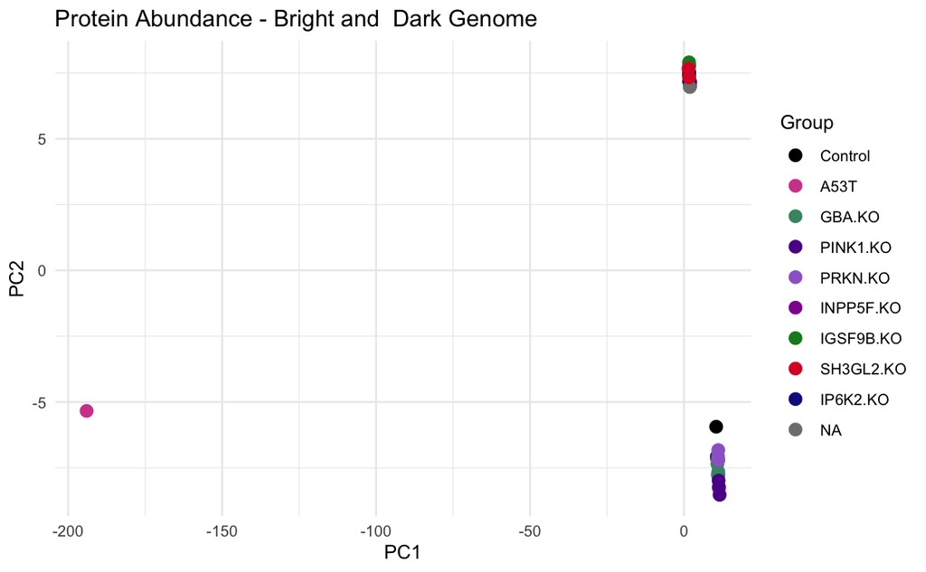

```r
# Apply log transformation (e.g., log2) to the combined dataframe
log_df <- df_clean_all
log_df[, -1] <- log2(log_df[, -1] + 1)  # Adding 1 to avoid log(0) issues


# Step 2: Transpose the data so that rows are samples and columns are proteins
df_t3 <- t(log_df)

# Step 3: Perform PCA
pca_result3 <- prcomp(df_t3, scale. = TRUE)

# Step 4: Extract the PCA scores for the first two dimensions
pca_scores3 <- as.data.frame(pca_result3$x)


# Step 1: Extract group information from row names
# Assuming row names are in the format "Group-Sample" (e.g., "A53T-1", "Control-1")
sample_names <- rownames(pca_scores3)
sample_groups <- gsub("-.*", "", sample_names)



# Step 2: Add the group information to the PCA scores dataframe
pca_scores3$Group <- factor(sample_groups, levels = c("Control","A53T", "GBA.KO", "PINK1.KO", "PRKN.KO", "INPP5F.KO", "IGSF9B.KO", "SH3GL2.KO","IP6K2.KO", "POOL"))


# take colours from Roxanne's plots: c("Control"= black, "INPP5F.KO" = Purple pinkish, "IGSF9B.KO" = green, "SH3GL2.KO" = red,"IP6K2.KO" = dark blue, "POOL"))
# green "#5c9e4b",
custom_colours <- c("black","#d34a98","#439472","#5c1c97","#9e69cf","#931ea0","#148825","#db072f","#111e8f","grey")

ggplot(pca_scores3, aes(x = PC1, y = PC2, color = Group)) +
  geom_point(size = 3) +
  labs(title = "Protein Abundance - Bright and  Dark Genome", x = "PC1", y = "PC2") +
 scale_color_manual(values = custom_colours)+
  theme_minimal()
```

```r
if (!require("BiocManager", quietly = TRUE))
    install.packages("BiocManager")
BiocManager::install("preprocessCore")
n

library(preprocessCore)
# Convert the data to a matrix
data_matrix <- as.matrix(df_clean_all)

# Perform quantile normalization
normalized_matrix <- normalize.quantiles(data_matrix)
# check if there are row and column names
rownames(normalized_matrix)
```

```r
colnames(normalized_matrix)
```

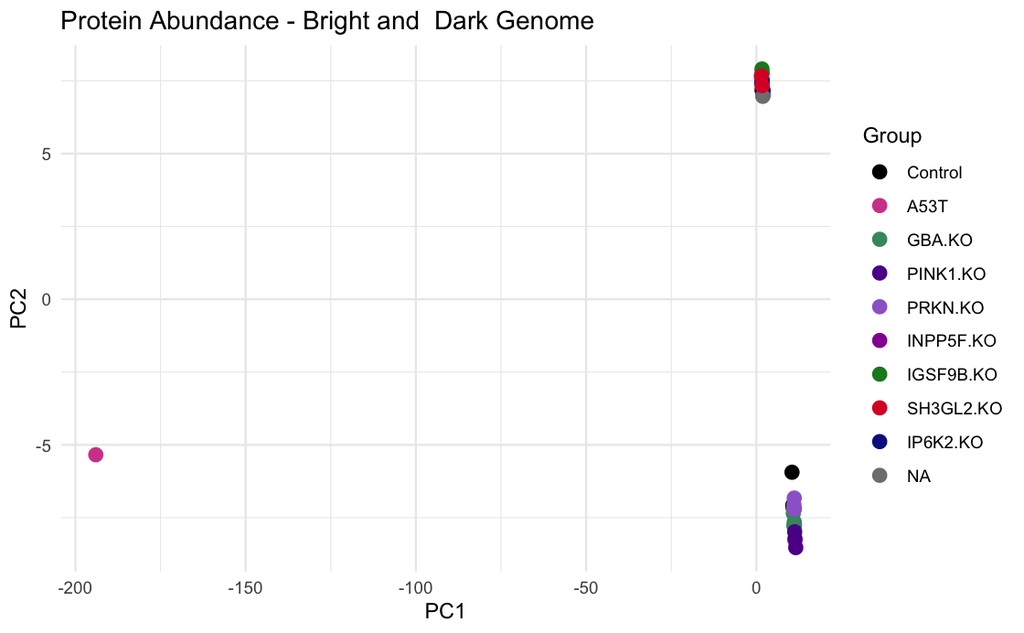

```r
# Step 2: Transpose the data so that rows are samples and columns are proteins
df_t3 <- t(log_df)

# Step 3: Perform PCA
pca_result3 <- prcomp(df_t3, scale. = TRUE)

# Step 4: Extract the PCA scores for the first two dimensions
pca_scores3 <- as.data.frame(pca_result3$x)


# Step 1: Extract group information from row names
# Assuming row names are in the format "Group-Sample" (e.g., "A53T-1", "Control-1")
sample_names <- rownames(pca_scores3)
sample_groups <- gsub("-.*", "", sample_names)



# Step 2: Add the group information to the PCA scores dataframe
pca_scores3$Group <- factor(sample_groups, levels = c("Control","A53T", "GBA.KO", "PINK1.KO", "PRKN.KO", "INPP5F.KO", "IGSF9B.KO", "SH3GL2.KO","IP6K2.KO", "POOL"))


# take colours from Roxanne's plots: c("Control"= black, "INPP5F.KO" = Purple pinkish, "IGSF9B.KO" = green, "SH3GL2.KO" = red,"IP6K2.KO" = dark blue, "POOL"))
# green "#5c9e4b",
custom_colours <- c("black","#d34a98","#439472","#5c1c97","#9e69cf","#931ea0","#148825","#db072f","#111e8f","grey")

ggplot(pca_scores3, aes(x = PC1, y = PC2, color = Group)) +
  geom_point(size = 3) +
  labs(title = "Protein Abundance - Bright and  Dark Genome", x = "PC1", y = "PC2") +
 scale_color_manual(values = custom_colours)+
  theme_minimal()
```

Heat map of expression for selected pathway lists:

Get pathway lists

```r
lyso.list <- read_excel("/Users/rhalenathomas/Downloads/Move_Data/DarkGenomeResult/List of genes for RNAseq or Proteomics/LYSOSOME_GENE LIST.xlsx")
```

Plotting Function

```r
colnames(df)
```

```
 [1] "Protein"    "A53T-1"     "A53T-2"     "A53T-3"     "Control-1"  "Control-2"  "Control-3"  "GBA.KO-1"   "GBA.KO-2"   "GBA.KO-3"   "PINK1.KO-1"
[12] "PINK1.KO-2" "PINK1.KO-3" "PRKN.KO-1"  "PRKN.KO-2"  "PRKN.KO-3"
```

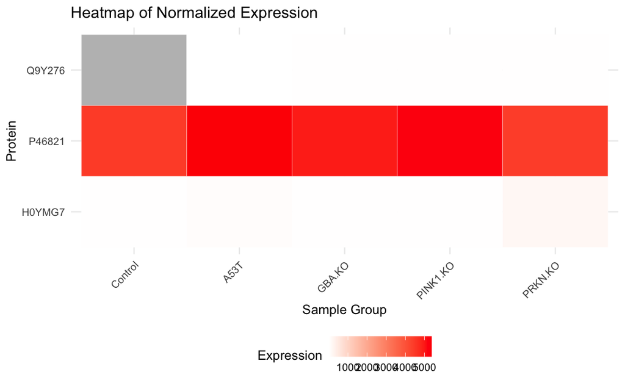

```r
plot_heatmap(df, protein_list = test, sample_groups = c("Control", "A53T", "GBA.KO", "PINK1.KO", "PRKN.KO"), group_colors = group_colors)
```

We need to convert the access numbers into protein/gene names

```r
install.packages("BiocManager")
```

```
Error in install.packages : Updating loaded packages
```

```r
BiocManager::install("biomaRt")
install.packages("BiocManager")
n
library(biomaRt)
```

```r
library(biomaRt)

# Connect to Ensembl database
ensembl <- useMart("ensembl", dataset = "hsapiens_gene_ensembl")

# Convert accession numbers in chunks
convert_accessions_in_chunks <- function(accessions, chunk_size = 1000) {
  results <- lapply(seq(1, length(accessions), by = chunk_size), function(i) {
    chunk <- accessions[i:min(i + chunk_size - 1, length(accessions))]
    getBM(attributes = c('uniprot_swissprot_accession', 'external_gene_name'),
          filters = 'uniprot_swissprot_accession',
          values = chunk,
          mart = ensembl)
  })
  do.call(rbind, results)
}

# Example usage
accessions <- c("A0A0B4J2D5", "A0AVT1", "A0MZ66", "A1L0T0", "A1X283", "A6NKG5", "O00116", "O00151", "O00154", "O00193")
converted <- convert_accessions_in_chunks(accessions)
```

```
Error in `collect()`:
! Failed to collect lazy table.
Caused by error in `db_collect()`:
! Arguments in `...` must be used.
✖ Problematic argument:
• ..1 = Inf
ℹ Did you misspell an argument name?
Backtrace:
  1. global convert_accessions_in_chunks(accessions)
 13. dbplyr:::collect.tbl_sql(., Inf)
 18. dbplyr::db_collect(x$src$con, sql, n = n, warn_incomplete = warn_incomplete, ...)
```

Try another converion method

```r
if (!require("BiocManager", quietly = TRUE))
    install.packages("BiocManager")

BiocManager::install("mygene")
n
library(mygene)
# Convert Uniprot accessions to gene names
accessions <- c("A0A0B4J2D5", "A0AVT1", "A0MZ66", "A1L0T0", "A1X283", "A6NKG5", "O00116", "O00151", "O00154", "O00193")

# Query using mygene
result <- queryMany(accessions, scopes = "uniprot", fields = c("symbol"), species = "human")
```

```
Finished
```

```r
# Check the result
print(result)
```

```
DataFrame with 10 rows and 4 columns
         query         _id   X_score      symbol
   <character> <character> <numeric> <character>
1   A0A0B4J2D5        8209   19.8793       GATD3
2       A0AVT1       55236   19.8794        UBA6
3       A0MZ66       57698   19.8793       SHTN1
4       A1L0T0       10994   19.8794       ILVBL
5       A1X283      285590   19.8794    SH3PXD2B
6       A6NKG5      388015   19.8793        RTL1
7       O00116        8540   19.8795        AGPS
8       O00151        9124   19.8793      PDLIM1
9       O00154       11332   19.8793       ACOT7
10      O00193       10944   19.8794    C11orf58
```

# convert protein accession numbers into symbols

|  | query | X_id | X_score | symbol | notfound |
| --- | --- | --- | --- | --- | --- |
| 1 | Q9Y276 | 617 | 19.87939 | BCS1L | NA |
| 2 | P08754 | 2773 | 19.87933 | GNAI3 | NA |
| 3 | A0A1X7SBT7 | NA | NA | NA | TRUE |
| 4 | Q9H4D0 | 64084 | 19.87933 | CLSTN2 | NA |
| 5 | Q496J9 | 22987 | 19.87955 | SV2C | NA |
| 6 | P62760 | 7447 | 19.87933 | VSNL1 | NA |

Now add into the dataframe

```r
# remove the extra columns
bright.ab <- bright.ab[, -c(14,18,19,21)]


colnames(bright.ab)
```

```
 [1] "Protein"    "A53T-1"     "A53T-2"     "A53T-3"     "Control-1"  "Control-2"  "Control-3"  "GBA.KO-1"   "GBA.KO-2"   "GBA.KO-3"   "PINK1.KO-1"
[12] "PINK1.KO-2" "PINK1.KO-3" "PRKN.KO-1"  "PRKN.KO-2"  "PRKN.KO-3"  "symbol"
```

# Plot lists

```r
df <- data.frame(bright.ab$symbol,bright.ab[,2:16])
colnames(df)
```

```
 [1] "bright.ab.symbol" "A53T.1"           "A53T.2"           "A53T.3"           "Control.1"        "Control.2"        "Control.3"        "GBA.KO.1"
 [9] "GBA.KO.2"         "GBA.KO.3"         "PINK1.KO.1"       "PINK1.KO.2"       "PINK1.KO.3"       "PRKN.KO.1"        "PRKN.KO.2"        "PRKN.KO.3"
```

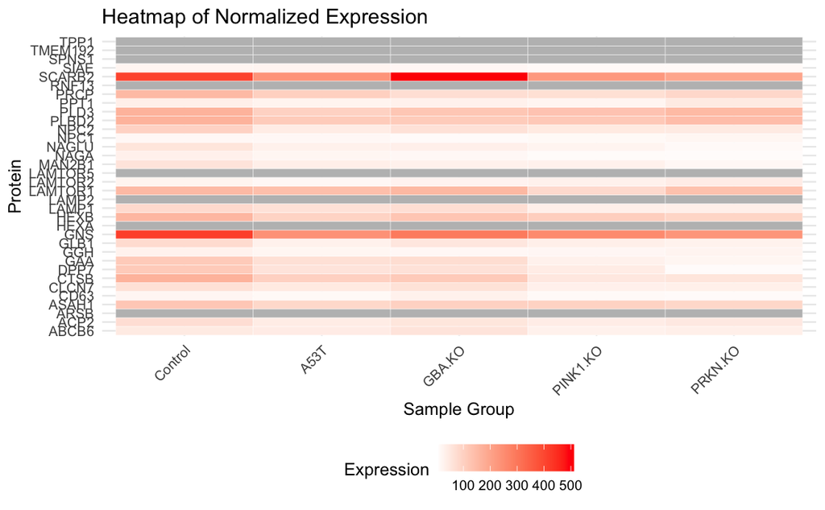

```r
colnames(df) <- c("symbol","A53T-1",  "A53T-2","A53T-3","Control-1", "Control-2",  "Control-3", "GBA.KO-1","GBA.KO-2",  "GBA.KO-3", "PINK1.KO-1",  "PINK1.KO-2",  "PINK1.KO-3", "PRKN.KO-1", "PRKN.KO-2",   "PRKN.KO-3" )

plot_heatmap(df, protein_list = lyso.list$`Gene name`, sample_groups = c("Control", "A53T", "GBA.KO", "PINK1.KO", "PRKN.KO"), group_colors = group_colors,protein_col = "symbol")
```

Update plotting function

Look at the Differential gene expression